# Связь сообществ зообентоса с концентрацией взвеси

Для оценки зависимости макробентоса от количества взвеси были построены две регрессионные модели, в которых в качестве зависимых переменных были рассмотрены суммарная численность организмов макробентоса и их суммарная биомасса (обе величины были логарифмированы). В качестве предикторов в обеих моделях были использованы следующие величины.

Построенные модели имели следующий вид:

$$log(N) = s(Lat, Long) + s(Suspended_matter:Community) + Community + \varepsilon$$

$$log(B) = s(Lat, Long) + s(Suspended\_matter:Community) + Community + \varepsilon$$

где $log(N)$ и $log(B)$ - зависимые переменные;  
$s(Lat, Long)$ - двумерная сглаживающая функция, описывающая связь с географическими координатами;  
$s(Suspended\_matter:Community)$ - две сглаживающие функции, описывающие связь с концентрацией взвешенных частиц, отдельно для каждого типа сообществ;  
$Community$ - тип сообщества;  
$\varepsilon$ - остатки.

Таблица 1. Характеристики сглаживающих функций, описывающих связь логарифма биомассы зообентоса с предикторами

| Предиктор | edf | ref.df | F | p-value |
| --- | --- | --- | --- | --- |
| s(Lat,Long) | 10.395835 | 14.307834 | 1.9175665 | 0.0335884 |
| s(Suspended_matter):CommunityПресноводное | 5.484846 | 6.482044 | 1.8113114 | 0.1010130 |
| s(Suspended_matter):CommunityМорское | 1.136678 | 1.247302 | 0.9221333 | 0.2227716 |

Параметрические компоненты модели

| Компонент модели | Значение параметра | SE | t | p-value |
| --- | --- | --- | --- | --- |
| (Intercept) | 1.610993 | 0.3475820 | 4.634856 | 0.0000128 |
| CommunityМорское | 1.349211 | 0.8476974 | 1.591619 | 0.1151835 |

Суммарная численность бентосных организмов демонстрировала статистически значимую связь с уровнем взвеси (Табл. 2) как в пресноводном, так и в морском сообществах. При этом в морском сообществе зависимость была прямолинейной (Рисунок 1). Важно отметить, что на тех станциях, которые были отнесены к морским сообществам, высокого уровня взвеси не наблюдалось. Однако и в этом диапазоне значений фактора, по мере увеличения количества взвеси обилие животных падало.

В пресноводном сообществе связь численности животных с обилием взвешенных частиц имела нелинейный характер (Рисунок 1). В диапазоне концентрации взвеси меньше 50 мг/л отмечалось резкое падение численности по мере увеличения концентрации взвеси. При более высокой концентрации взвеси обилие животных было на стабильно низком уровне.

Таким образом, суммарная численность бентосных животных, как в пресноводном сообществе, так и в морском, резко убывает по мере увеличения концентрации взвеси. Важно отметить, что даже небольшое увеличение концентрации взвеси значительно сокращает суммарное обилие донных беспозвоночных. Высокие значения обилия донных животных в пресноводном сообществе отмечаются только при концентрации взвешенных частиц меньше 100 мг/л (Рисунок 2).

Таблица 2. Характеристики непараметрических сглаживающих функций, описывающих связь логарифма общей численнсти зообентоса с предикторами

| Предиктор | edf | ref.df | F | p-value |
| --- | --- | --- | --- | --- |
| s(Lat,Long) | 12.810968 | 17.289528 | 4.937332 | 0.0000001 |
| s(Suspended_matter):CommunityFresh | 7.033968 | 7.658132 | 3.586899 | 0.0014003 |
| s(Suspended_matter):CommunityMarine | 1.000000 | 1.000000 | 5.313411 | 0.0236650 |

Параметрические компоненты модели

| Компонент модели | Значение параметра | SE | t | p-value |
| --- | --- | --- | --- | --- |
| (Intercept) | 4.891341 | 0.2857917 | 17.115053 | 0.00000 |
| CommunityMarine | 1.432393 | 0.6511665 | 2.199734 | 0.03067 |

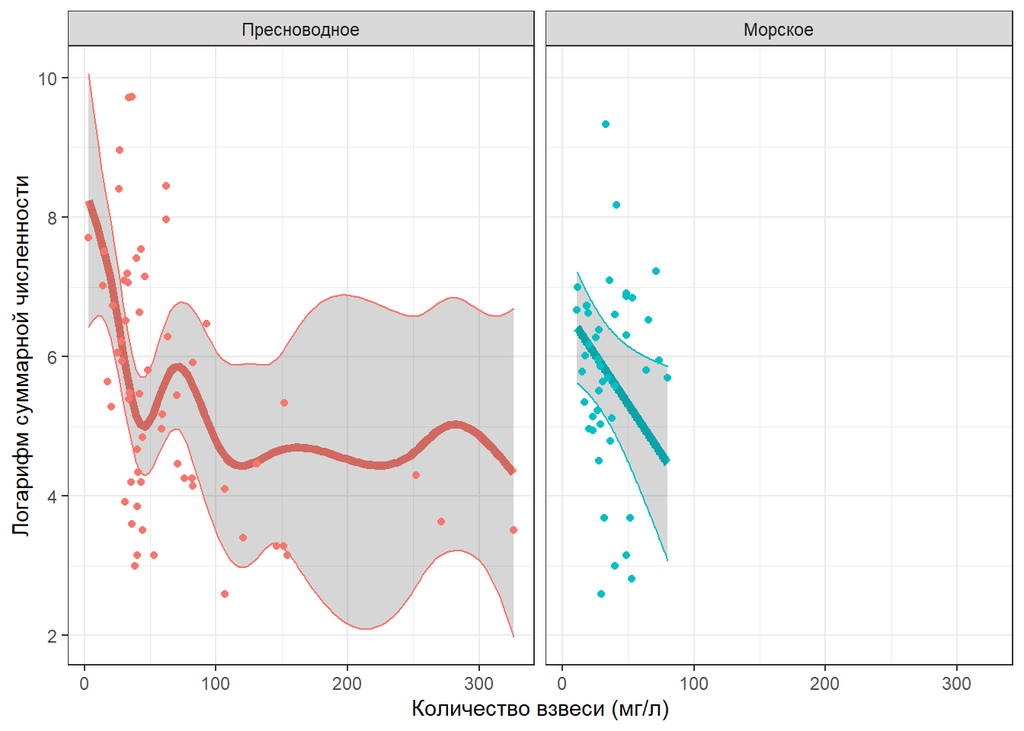

**Рисунок 1.** Зависимость суммарной численности бентосных организмов от концентрации взыешенных частиц. Для визуализации модели значения географических координат были усреднены.

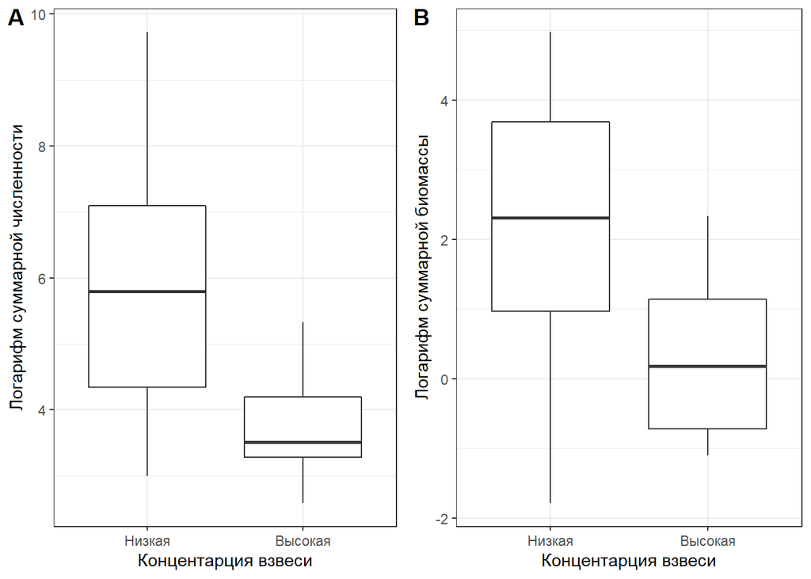

**Рисунок 2.** Значения суммарной численности (A) и биомассы (B) бентосных организмов в пресноводном сообществе при низкой (менее 100 мг/л) и высокой (более 100 мг/л) концентрации взвешенных частиц.